# State MSM Profile: **Pennsylvania**

#### Gettysburg Metropolitan Statistical Area

The Gettysburg MSA had a population of 843 MSM, or 0.5% of all MSM in Pennsylvania. Of the 38,734 adult men in Gettysburg, an estimated 2.2% were MSM.

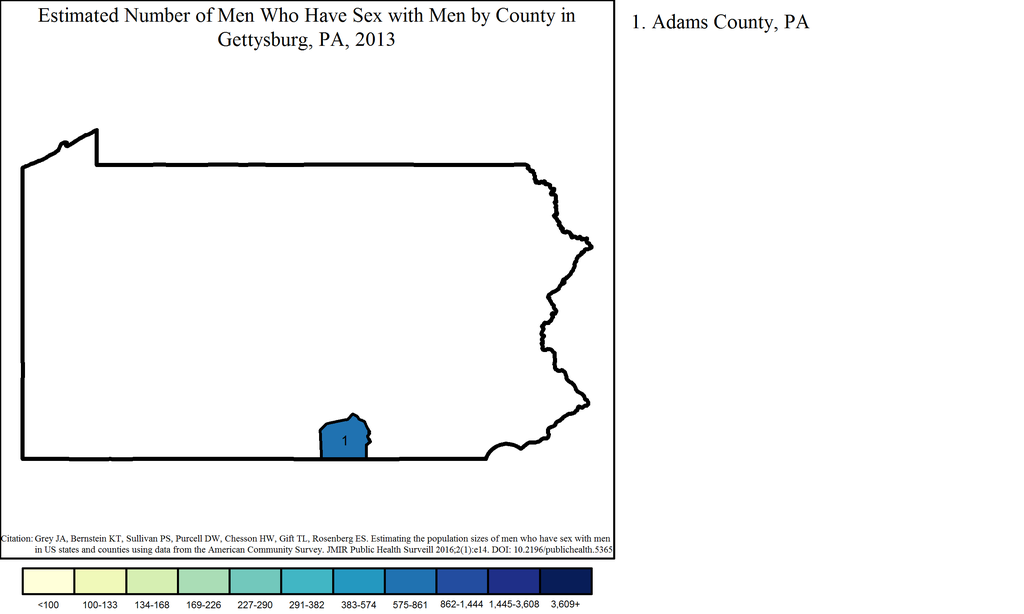

Note: Range cutpoints for the map are based on the distribution of MSM among all counties in the United States.

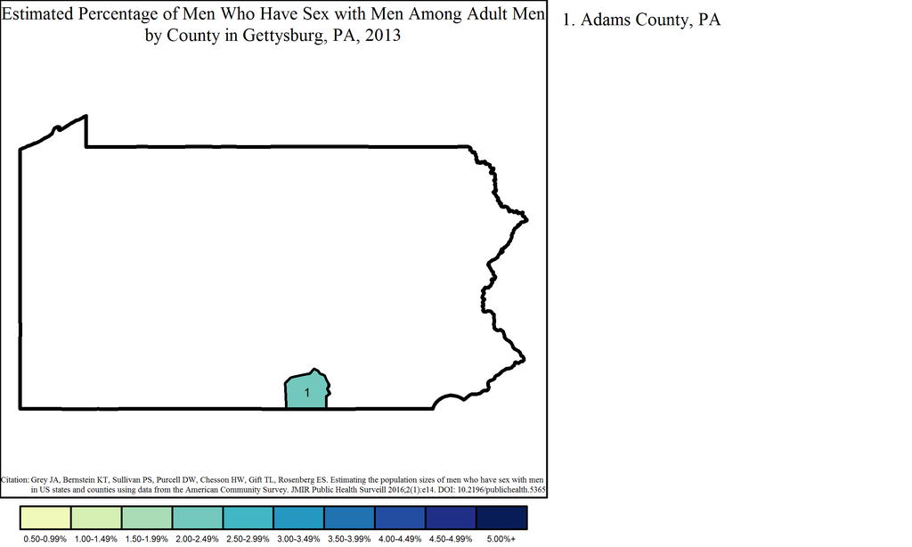

#### Chambersburg-Waynesboro Metropolitan Statistical Area

The Chambersburg-Waynesboro MSA had a population of 758 MSM, or 0.5% of all MSM in Pennsylvania. Of the 55,436 adult men in Chambersburg-Waynesboro, an estimated 1.4% were MSM.

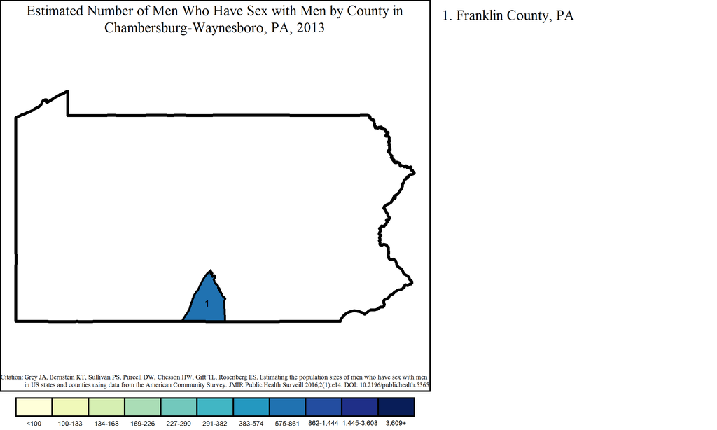

Note: Range cutpoints for the map are based on the distribution of MSM among all counties in the United States.

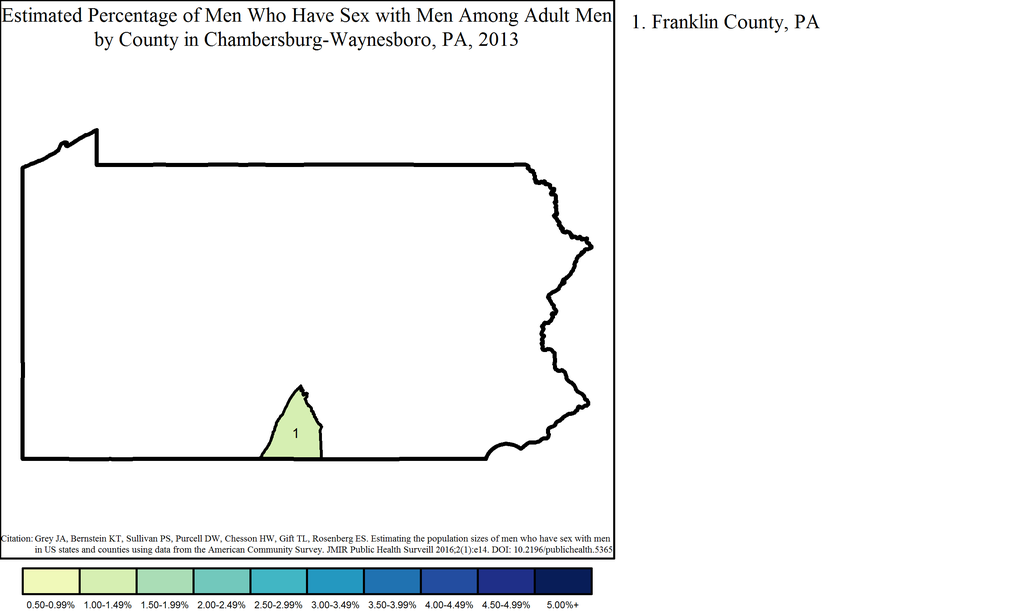

#### Altoona Metropolitan Statistical Area

The Altoona MSA had a population of 755 MSM, or 0.5% of all MSM in Pennsylvania. Of the 48,074 adult men in Altoona, an estimated 1.6% were MSM.

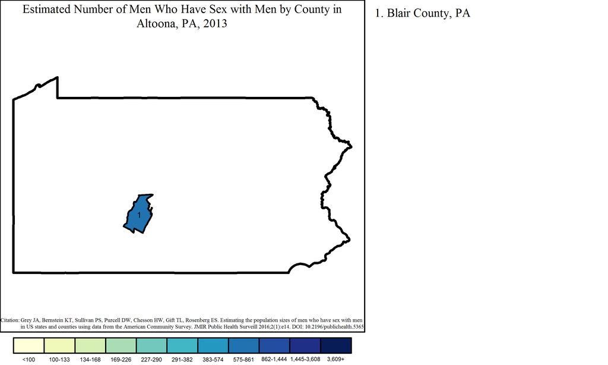

Note: Range cutpoints for the map are based on the distribution of MSM among all counties in the United States.

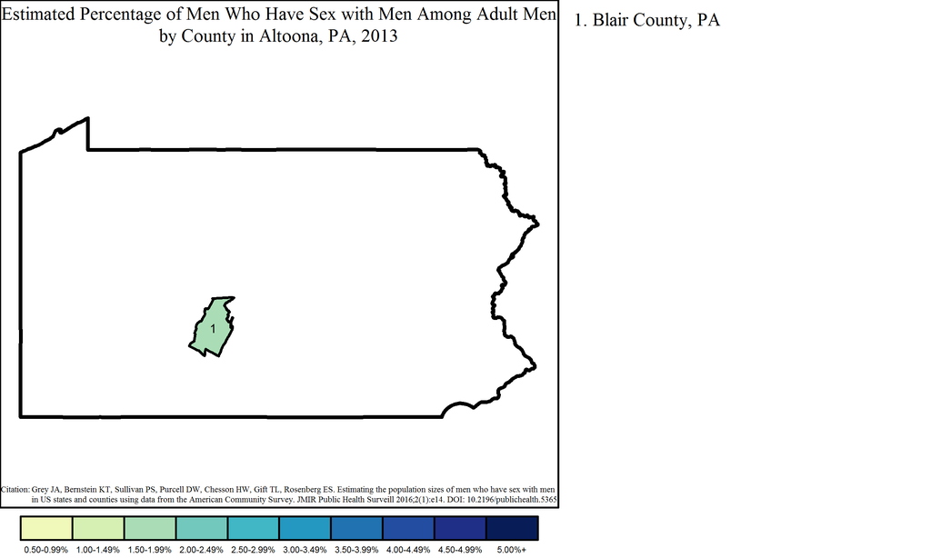

#### Johnstown Metropolitan Statistical Area

The Johnstown MSA had a population of 741 MSM, or 0.5% of all MSM in Pennsylvania. Of the 56,252 adult men in Johnstown, an estimated 1.3% were MSM.

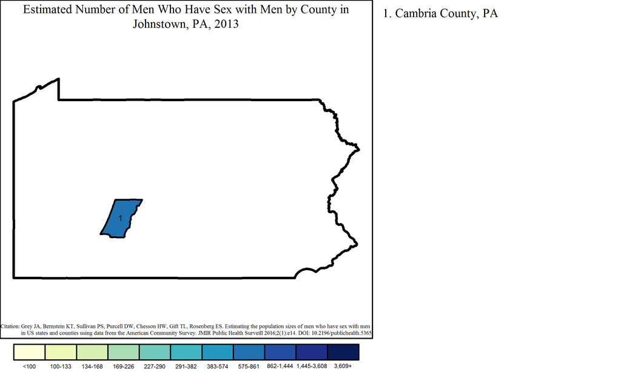

Note: Range cutpoints for the map are based on the distribution of MSM among all counties in the United States.

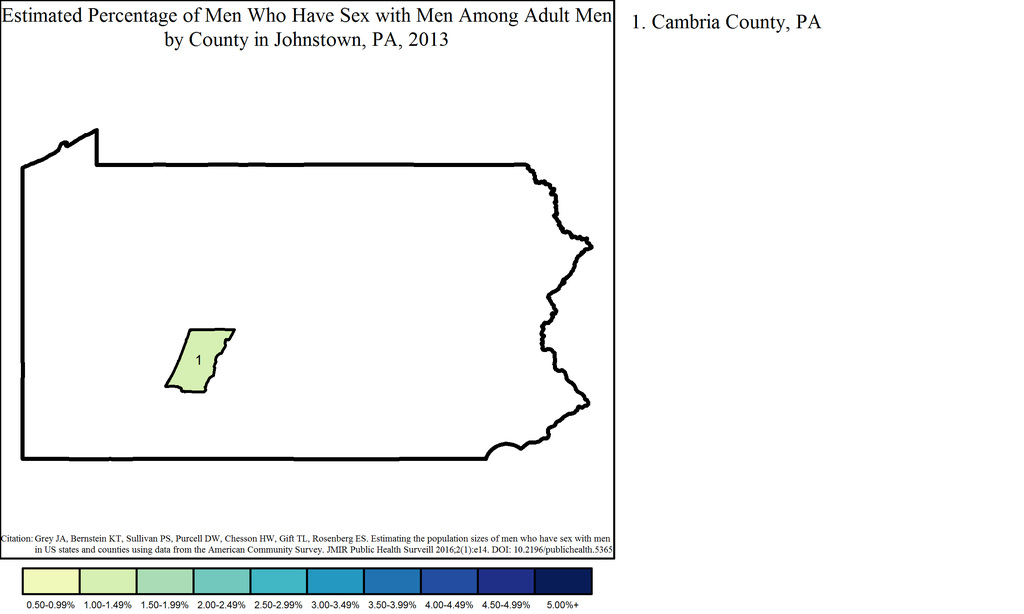

#### Youngstown-Warren-Boardman Metropolitan Statistical Area

The Youngstown-Warren-Boardman MSA overlaps two states: Ohio and Pennsylvania. The Pennsylvania portion of the MSA had 605 MSM, or 0.4% of all MSM in the state and 16.7% of the 3,631 MSM in the MSA. Of 44,290 adult men in the Pennsylvania part of Youngstown-Warren-Boardman, 1.4% were MSM. This was less than the overall percentage of MSM among adult men in the MSA, which was 1.7% of adult men (3,631 out of 211,654).

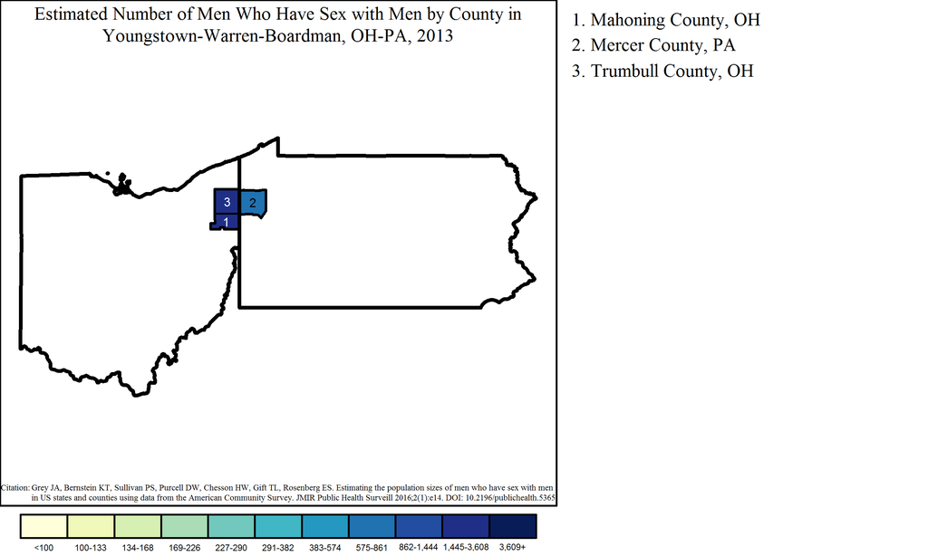

Note: Range cutpoints for the map are based on the distribution of MSM among all counties in the United States.

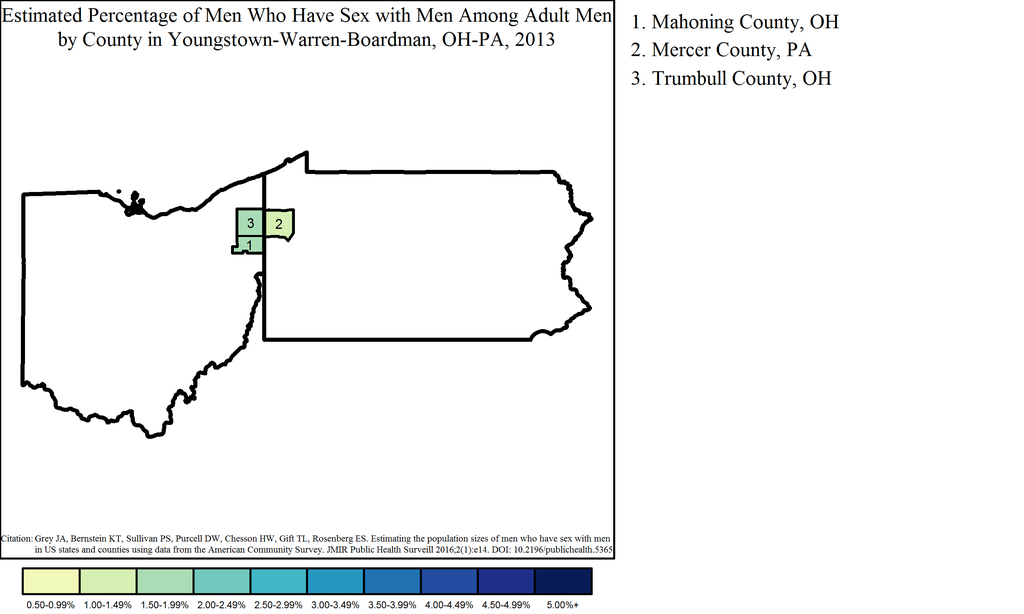

#### Bloomsburg-Berwick Metropolitan Statistical Area

The Bloomsburg-Berwick MSA had a population of 465 MSM, or 0.3% of all MSM in Pennsylvania. Of the 32,632 adult men in Bloomsburg-Berwick, an estimated 1.4% were MSM.

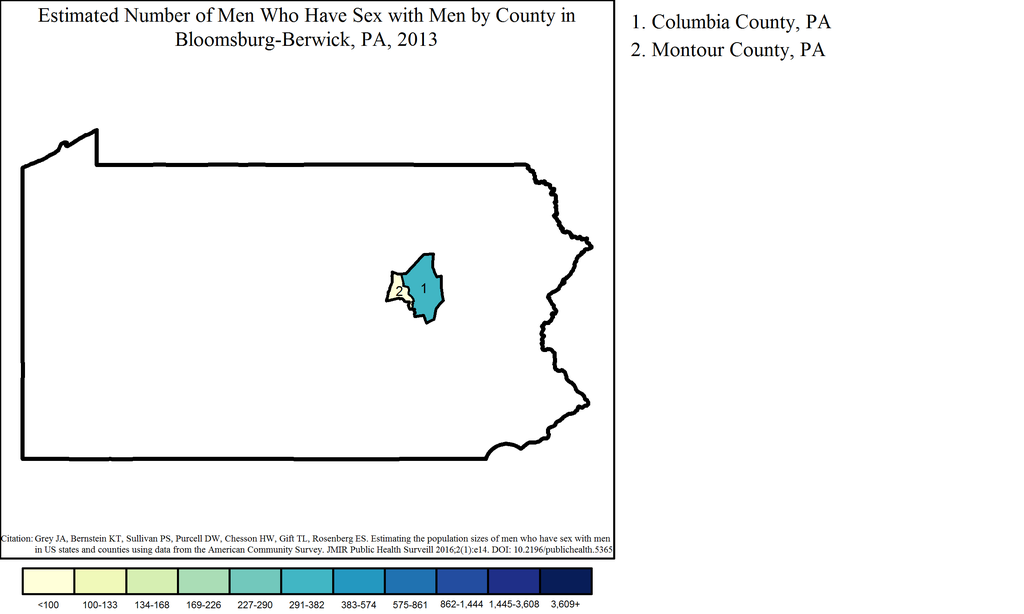

Note: Range cutpoints for the map are based on the distribution of MSM among all counties in the United States.

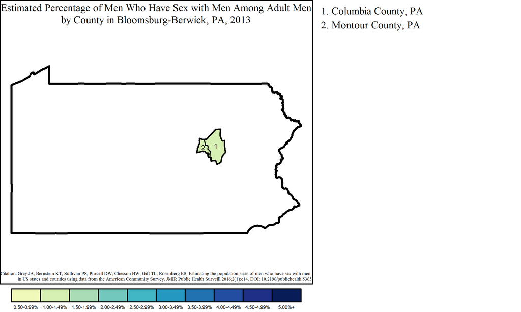